# MANTIS – a hub for monitoring with automated and novel technologies based on image and sound

MANTIS

A hub for Monitoring with Automated and Novel Technologies based on Image and Sound

Sensors are already deployed across Europe. MANTIS aims to connect them into a transnational monitoring system, rather than isolated national deployments.

- Biodiversa+ WP2 · Task 2.5.3 additional activity
- Aarhus University with the Nature Conservation Agency CZ
- 1 January 2027 – 30 September 2028
- €796,850.18 requested
- Core Activity 3 primary · CA2 and CA4 secondary

## The proposal in one figure

[figure not shown]

MANTIS runs a single quality-controlled chain from sensors in the field to policy indicators. Package 1 improves the schemes that feed the chain, Package 2 carries data through verification, benchmarking and publication, and Package 3 builds the capacity that keeps it running.

The numbered gates on the connectors – deployment registration, expert verification, AI benchmarking, standards conformance – are what MANTIS adds. Most of what lies either side of them already exists in Europe.

## Start here

5 slides · 5–6 minutes Core pitch What MANTIS is, the problem it answers, the chain figure, what exists at the end of the activity, what it costs. A brief introduction. 17 slides · 10–13 minutes Extended pitch Existing deployments and technologies, three bottlenecks, five objectives, nineteen activities, budget tiers, the plan for after 2028. One slide per package on how partners can contribute. Speaker notes on every slide.

## What the activity does

**Connect data acquisition** – align protocols, deployments and annotations across partners. Extend spatial and taxonomic coverage with new sensor deployments. Package 1 · seven activities · Core Activity 2

**Connect the data** – harmonise datasets and metadata. Ensure flow from images and sounds to quality-controlled indicators, including transnational benchmarking of AI models. Package 2 · five activities · Core Activity 3, primary

**Connect the community** – link the users of these technologies to one another, and to the skills and resources that sustain a transnational effort. Package 3 · seven activities · Core Activity 4

Nineteen activities in all, with nine deliverables and sixteen milestones between 1 January 2027 and 30 September 2028. MANTIS could develop into a Thematic Hub associated with an EBOCC. It sets up no new operational structure: outputs are hosted on GitHub Pages, GBIF and Zenodo, and verification capacity rests on statutory Habitats and Birds Directive duties.

## Objectives and deadlines

|  | Target and indicator | Deadline |
| --- | --- | --- |
| **O1** Deployment registration | 100% of active AMI, CamAlien and acoustic deployments across ≥8 partner countries, registered and machine-readable in a Camtrap DP-compliant master database | 30 Sep 2028 |
| **O2** Policy-relevant indicators | ≥4 finalised indicators live on the MANTIS dashboard, each mapped to NRR Art. 10 / EU-PoMS, the Habitats Directive, the Birds Directive or IAS Regulation 1143/2014, and auto-updating from GBIF | 30 Sep 2028 |
| **O3** Verified annotations | ≥5,000 expert-verified annotations published under FAIR principles, including ≥2,000 NewtCam annotations; ≥20% reviewed by experts from ≥2 countries | 31 Dec 2027 |
| **O4** Training | 25 summer-school participants from ≥12 countries; ≥20 distinct organisations attending ≥1 of the 8 online events | 30 Jun 2028 |
| **O5** Roadmap beyond 2028 | Roadmap endorsed by ≥2/3 of partners at BioMonWeek 2028, naming ≥2 concrete funding or hosting pathways | 30 Jun 2028 |

## The devices, in the field

Three device families: AMI traps for nocturnal insects, acoustic recorders for birds, bats and amphibians, and the vehicle-mounted CamAlien for invasive plants along roads. These are existing partner deployments, which MANTIS would register, upgrade and benchmark.

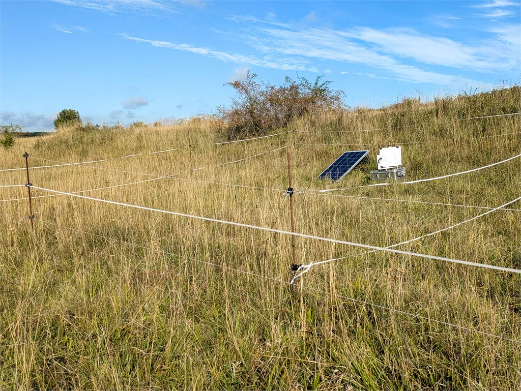

AMI trapA camera trap for nocturnal insects, running unattended on solar power in dry grassland. Activity 1.4 retrofits deployments like this one with modems and SIM cards so health checks and image transfer happen remotely instead of by field visit.

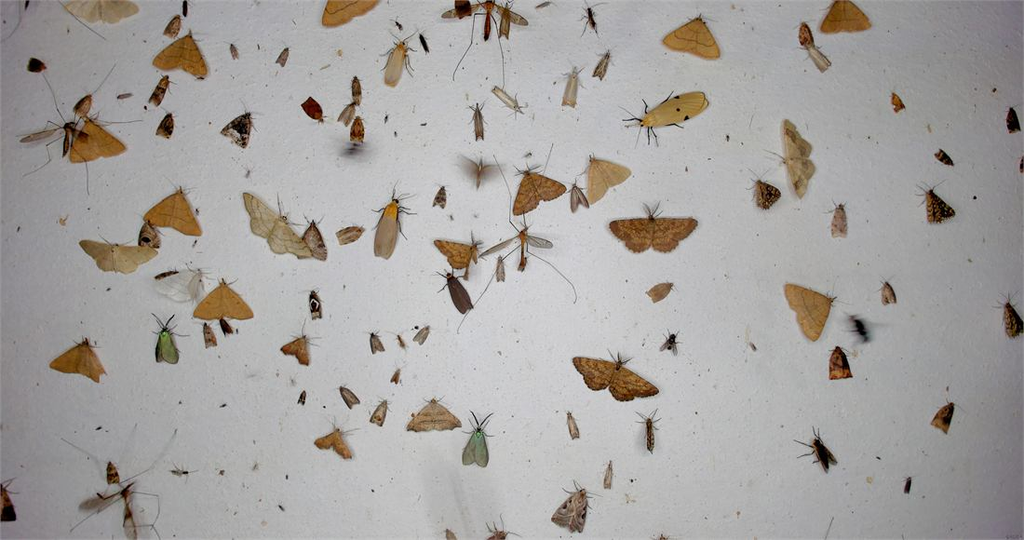

One frame, one nightAn illuminated sheet, photographed at intervals through the night. The volume of images like this has outgrown the capacity to verify them.

[figure not shown]

Acoustic recordersSong Meter units at a meadow edge, recording audible and ultrasound. Many deployed recorders still need a field visit to retrieve data. Activity 1.4 upgrades them for solar power and cellular remote access.

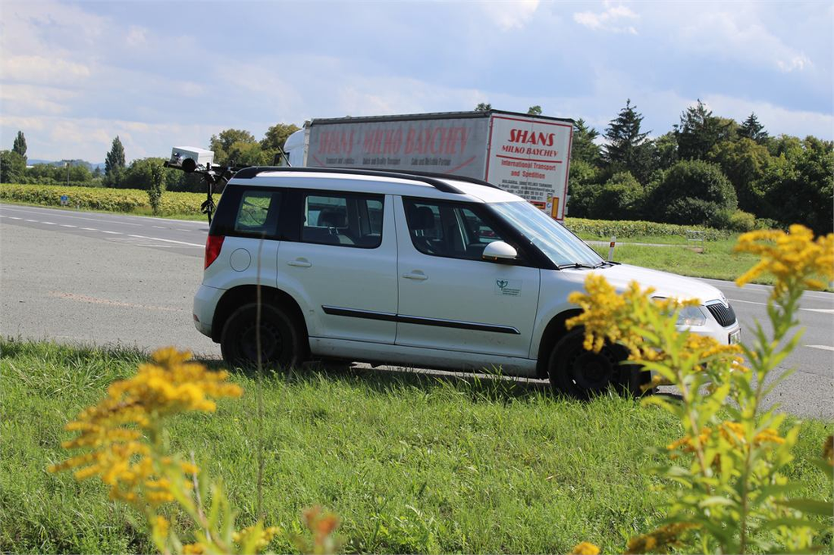

CamAlienA high-speed, car-mounted camera system with automated image capture and GPS processing. Roads are a key route for the spread of invasive alien species. Mapping plants along them supports early detection under IAS Regulation 1143/2014.

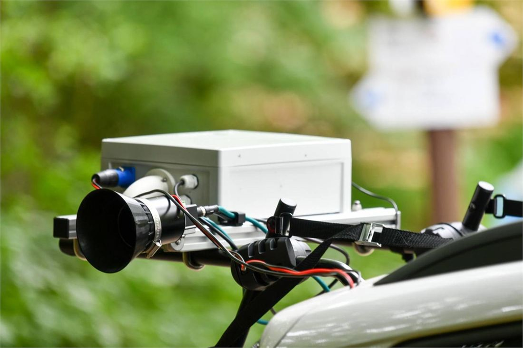

The rig up closeLens, housing and control box on the roof bar. Activity 1.4 installs new onboard computers and GPS, so images can be classified on the vehicle in real time.

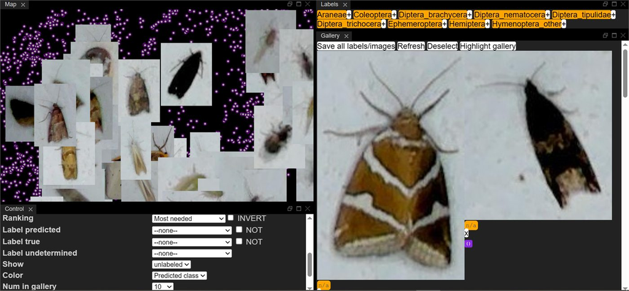

Expert verificationExperts review AI-proposed identifications to build the reference dataset used for benchmarking – at least 5,000 verified annotations, a fifth of them checked in two countries, by the end of 2027.

## Related initiatives

Schemes, projects and infrastructures that MANTIS builds on, feeds into, or stays interoperable with.

[The partnership Biodiversa+ The European Biodiversity Partnership. MANTIS is an additional activity under WP2, Task 2.5.3.](https://www.biodiversa.eu/) [Pilot 2.6.2 IAS pilot Image-based monitoring of invasive alien species – an AMI trap and a CamAlien unit in ten countries. Takes on the registration system and the Camtrap DP implementations.](https://www.biodiversa.eu/biodiversity-monitoring/pilots/ias-pilot/) [Pilot 2.6.5 ABMS pilot Automated Biodiversity Monitoring Stations – AMI traps and acoustic recorders in three habitat types across eleven countries.](https://www.biodiversa.eu/biodiversity-monitoring/pilots/abms-pilot/) [Pilot 2.6.8 BiodivPond Standardised pond monitoring, with acoustic recorders in ten countries. The underwater acoustic pilot and the NewtCam annotations connect here.](https://biodivpond.github.io/) [Horizon Europe MAMBO AI models for image and sound recognition in EU biodiversity monitoring. MANTIS reuses them for benchmarking instead of training its own.](https://www.mambo-project.eu/) [Biodiversa+ project TABMON Passive acoustic monitoring across four countries, producing EBVs from soundscapes. Shared metadata structures and acoustic pipelines.](https://tabmon-eu.nina.no/) [EU research results CORDIS The Commission's record of the EU-funded projects MANTIS builds on, MAMBO among them – factsheets, deliverables and results.](https://cordis.europa.eu/project/id/101060639)

**Contact** – Jamie Alison, Aarhus University, jalison@ecos.au.dk · Jonas Gaigr, Nature Conservation Agency CZ, jonas.gaigr@aopk.gov.cz

Numbers and claims on this site are taken from the proposal document. The figure is generated from a declarative spec and checked against facts extracted from that document. Source and build pipeline: github.com/jonasgaigr/mantis-hub.